# Introduction to R for Economic Analysis

Inter-American Development Bank Workshop

Angelo Mazzocca

2025-11-25

# Learning Objectives

- Understand the **R language**
- Use RStudio
- Work with **data types**
- Import/export data
- Use **tidyverse**
- Visualize with **ggplot2**

# Why R?

**Comprehensive Statistical Tools:** R includes many statistical functions and models, making it the ideal choice for data analysis.

**Customizable Visualizations:** R’s visualization tools allows for customizations for a simple bar chart or a detailed heatmap.

**Extensive Community Support:** R has a large user base and there are countless resources, forums and tutorials available.

**Highly Extendable:** The availability of over 15,000 R packages means we can extend R’s functionality to suit any project or need.

# Setup R and RStudio

To install R, go to https://cran.r-project.org/ and download the latest version of R for Windows, Mac or Linux. When installing select base and default options.

Now that R is installed, we can install RStudio. Navigate to the RStudio downloads page: https://rstudio.com/products/rstudio/download/.

Select Download Rstudio Desktop, when installed search in your computer and open RStudio.

# RStudio

Is the preferred graphical front-end to use R

[figure not shown]

# RStudio

[figure not shown]

Divided into 4 quadrants:

- Console (bottom-left): Where the code is executed
- Script (top-left): Where the script file is loaded
- Global environment (top-right): Where objects you create are stored
- Auxiliary box (bottom-right): Where plots, packages, help and file directory is displayed

# Package installation

Run this manually in R console first

```
install.packages(c("tidyverse","lubridate","openxlsx"))
```

# First R program

Print a simple message

```r
print("Hello world")
```

```
[1] "Hello world"
```

# Operators

- Arithmetic operators

```r
2 + 5
```

```
[1] 7
```

```r
2 * 5
```

```
[1] 10
```

```r
2^5
```

```
[1] 32
```

- Logical operators

```r
2 + 5 > 2 * 5
```

```
[1] FALSE
```

```r
2^5 != 2 * 5
```

```
[1] TRUE
```

- Assignment operator

```r
country <- "The Bahamas"
country
```

```
[1] "The Bahamas"
```

# Data types

The main data types in R are: Character (string), Numeric, and Logical (TRUE or FALSE)

```r
country <- "The Bahamas"
gdp <- 12500
is_island <- TRUE

class(country)
```

```
[1] "character"
```

```r
class(gdp)
```

```
[1] "numeric"
```

```r
class(is_island)
```

```
[1] "logical"
```

# Data structures

- Vectors

List of items that are of the same type. To combine the list of items into a vector, use the c() function and separate the items by a comma.

```r
x <- c(10, 20, 30)
x
```

```
[1] 10 20 30
```

```r
x <- c(10, 20, "apple", "pineapple",
       10<20, 10<5)
x
```

```
[1] "10"        "20"        "apple"     "pineapple" "TRUE"      "FALSE"
```

# Data structures

- Matrices

Two dimensional data set with columns and rows.

```r
x <- matrix(c(1,2,3,4,5,6), nrow = 3, ncol = 2)
x
```

```
     [,1] [,2]
[1,]    1    4
[2,]    2    5
[3,]    3    6
```

# Data frames

Data displayed in a format as a table.

Data Frames can have different types of data inside it. But each column should have the same type of data.

```r
library(tidyverse)

df <- data.frame(
  country = c("US","UK","BS"),
  gdp = c(23000,18000,5000)
)

df
```

```
  country   gdp
1      US 23000
2      UK 18000
3      BS  5000
```

# Data exploration

To assess the data types of various columns in a data frame use str():

```r
str(df)
```

```
'data.frame':   3 obs. of  2 variables:
 $ country: chr  "US" "UK" "BS"
 $ gdp    : num  23000 18000 5000
```

# Data exploration

You can click on the object created (df) or use the View() function to open a new tab to display the data frame

```
View(df)
```

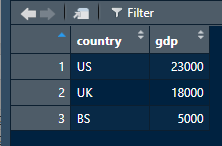

# Selecting values

There are two ways to access a subset of a data frame:

- $ operator: Allows you to access the content of a selected column

```r
df$country
```

```
[1] "US" "UK" "BS"
```

- [] operator: allows you to access rows and columns, as well as single values inside them

```r
df["country"]
```

```
  country
1      US
2      UK
3      BS
```

```r
df[1,]
```

```
  country   gdp
1      US 23000
```

```r
df[1,1]
```

```
[1] "US"
```

# Conditionals

The If statement shows an output if the condition set is True, if False you can set up another condition using the Else If statement, if False again the Else statement is triggered.

```r
score <- 72

if(score>=90){
 print("A")
} else if(score>=80){
 print("B")
} else {
 print("Below B")
}
```

```
[1] "Below B"
```

# Loops

- For loop. It is used for iterating over a sequence:

```r
for(i in 1:5){ print(i) }
```

```
[1] 1
[1] 2
[1] 3
[1] 4
[1] 5
```

- While loop. It can execute a set of statements as long as a condition is TRUE:

```r
i <- 1
while (i < 6) {
  print(i)
  i <- i + 1}
```

```
[1] 1
[1] 2
[1] 3
[1] 4
[1] 5
```

- Sapply. Works as a for loop but more efficient:

```r
# The output of sapply is a vector, unlike the for loop
sapply(1:5, function (i) i^2)
```

```
[1]  1  4  9 16 25
```

# Tidyverse

Is a collection of R packages designed to make data analysis easier and more intuitive.

The main advantage is the use of the pipe operator (%>%).

It allows you to take the value of previous function and feed it into the next function

Benefits: We can read the code in a logical order. We do not introduce temporary variables that we overwrite

```r
df %>%
  filter(gdp>10000) %>%
  mutate(gdp_million=gdp/1000) %>%
  arrange(desc(gdp))
```

```
  country   gdp gdp_million
1      US 23000          23
2      UK 18000          18
```

# Tidyverse functions

- filter() allows you to select a subset of rows in a data frame.
- arrange() sorts the observations in a dataset in ascending or descending order.
- mutate() allows you to update or create new columns of a data frame.
- summarise() allows you to turn many observations into a single data point.

# Summaries

```r
df %>%
 summarise(
   avg_gdp = mean(gdp),
   median_gdp = median(gdp),
   sd_gdp  = sd(gdp)
 )
```

```
   avg_gdp median_gdp   sd_gdp
1 15333.33      18000 9291.573
```

# Joining

Create sample dataframes for joining exercise with three years

```r
gdp <- data.frame(
  country = c("US", "UK", "BS", "US", "UK", "BS", "US", "UK", "BS"),
  year = c(2021, 2021, 2021, 2022, 2022, 2022, 2023, 2023, 2023),
  gdp = c(20895, 17234, 11876, 22418, 16987, 12654, 22783, 18321, 12189),
  growth_rate = c(0.0187, 0.0162, 0.0231, 0.0512, 0.0268, 0.0194, 0.0428, 0.0315, 0.0183)
)

stocks <- data.frame(
  country = c("US", "UK", "BS", "US", "UK", "BS", "US", "UK", "BS"),
  year = c(2021, 2021, 2021, 2022, 2022, 2022, 2023, 2023, 2023),
  stock_index = c(3924, 3117, 1428, 4385, 2976, 1618, 4632, 3284, 1531),
  market_cap = c(41234, 28765, 15892, 41987, 32134, 14678, 46789, 30567, 16432)
)
```

# Joining

```r
gdp
```

```
  country year   gdp growth_rate
1      US 2021 20895      0.0187
2      UK 2021 17234      0.0162
3      BS 2021 11876      0.0231
4      US 2022 22418      0.0512
5      UK 2022 16987      0.0268
6      BS 2022 12654      0.0194
7      US 2023 22783      0.0428
8      UK 2023 18321      0.0315
9      BS 2023 12189      0.0183
```

```r
stocks
```

```
  country year stock_index market_cap
1      US 2021        3924      41234
2      UK 2021        3117      28765
3      BS 2021        1428      15892
4      US 2022        4385      41987
5      UK 2022        2976      32134
6      BS 2022        1618      14678
7      US 2023        4632      46789
8      UK 2023        3284      30567
9      BS 2023        1531      16432
```

# Joining

left_join() allows you to keep all rows of the left df (gdp) and adds all matching rows from the right df (stocks).

```r
merged_df <- left_join(gdp,stocks,by=c("country","year"))
merged_df
```

```
  country year   gdp growth_rate stock_index market_cap
1      US 2021 20895      0.0187        3924      41234
2      UK 2021 17234      0.0162        3117      28765
3      BS 2021 11876      0.0231        1428      15892
4      US 2022 22418      0.0512        4385      41987
5      UK 2022 16987      0.0268        2976      32134
6      BS 2022 12654      0.0194        1618      14678
7      US 2023 22783      0.0428        4632      46789
8      UK 2023 18321      0.0315        3284      30567
9      BS 2023 12189      0.0183        1531      16432
```

# Descriptive statistics

```r
merged_df
```

```
  country year   gdp growth_rate stock_index market_cap
1      US 2021 20895      0.0187        3924      41234
2      UK 2021 17234      0.0162        3117      28765
3      BS 2021 11876      0.0231        1428      15892
4      US 2022 22418      0.0512        4385      41987
5      UK 2022 16987      0.0268        2976      32134
6      BS 2022 12654      0.0194        1618      14678
7      US 2023 22783      0.0428        4632      46789
8      UK 2023 18321      0.0315        3284      30567
9      BS 2023 12189      0.0183        1531      16432
```

```r
summary(merged_df[c('country','gdp','stock_index')])
```

```
   country               gdp         stock_index
 Length:9           Min.   :11876   Min.   :1428
 Class :character   1st Qu.:12654   1st Qu.:1618
 Mode  :character   Median :17234   Median :3117
                    Mean   :17262   Mean   :2988
                    3rd Qu.:20895   3rd Qu.:3924
                    Max.   :22783   Max.   :4632
```

# Setting up the working directory

It’s just a file path on your computer that sets the default location of any files you read into R, or save out of R.

```r
# Use this function to assess what is your current working directory
getwd()
```

```
[1] "C:/Users/agmaz/Documents"
```

```r
# You can change the working directory a your convinience:
#setwd("C:\\Users\\User\\Documents\\R")
```

# Import & Export

```r
library(openxlsx)

data_csv <- read.csv("gdp.csv", sep = ",")
data_csv
```

```
   date real_gdp
1  2015  12252.4
2  2016  12110.7
3  2017  12519.0
4  2018  12819.2
5  2019  12711.7
6  2020  10158.0
7  2021  11944.4
8  2022  13243.7
9  2023  13647.4
10 2024  14108.5
```

```r
write.csv(data_csv,"output.csv")
write.xlsx(data_csv,"output.csv")
#Check your working directory for this file
```

# Import & Export

```r
gdp_bhs  <- read.xlsx("gdp.xlsx")
gdp_bhs
```

```
   date real_gdp
1  2015  12252.4
2  2016  12110.7
3  2017  12519.0
4  2018  12819.2
5  2019  12711.7
6  2020  10158.0
7  2021  11944.4
8  2022  13243.7
9  2023  13647.4
10 2024  14108.5
```

```r
stocks_bhs <- read.xlsx("stocks.xlsx")
stocks_bhs
```

```
   date bisx_index
1  2015       1824
2  2016       1938
3  2017       2064
4  2018       2110
5  2019       2232
6  2020       2092
7  2021       2228
8  2022       2645
9  2023       2852
10 2024       3008
```

# Import & Export

```r
bhs_data <- gdp_bhs %>%
  left_join(stocks_bhs, by = "date") %>%
  data.frame()
bhs_data
```

```
   date real_gdp bisx_index
1  2015  12252.4       1824
2  2016  12110.7       1938
3  2017  12519.0       2064
4  2018  12819.2       2110
5  2019  12711.7       2232
6  2020  10158.0       2092
7  2021  11944.4       2228
8  2022  13243.7       2645
9  2023  13647.4       2852
10 2024  14108.5       3008
```

# Dates

There is one more data type, the **date** type and it’s recommended to set up the date column accordingly in data frames

```r
library(lubridate)
bhs_data$date <- make_date(bhs_data$date)
bhs_data
```

```
         date real_gdp bisx_index
1  2015-01-01  12252.4       1824
2  2016-01-01  12110.7       1938
3  2017-01-01  12519.0       2064
4  2018-01-01  12819.2       2110
5  2019-01-01  12711.7       2232
6  2020-01-01  10158.0       2092
7  2021-01-01  11944.4       2228
8  2022-01-01  13243.7       2645
9  2023-01-01  13647.4       2852
10 2024-01-01  14108.5       3008
```

```r
str(bhs_data)
```

```
'data.frame':   10 obs. of  3 variables:
 $ date      : Date, format: "2015-01-01" "2016-01-01" ...
 $ real_gdp  : num  12252 12111 12519 12819 12712 ...
 $ bisx_index: num  1824 1938 2064 2110 2232 ...
```

# ggplot2 line plot

ggplot2 is a powerful tool for visualizing data:

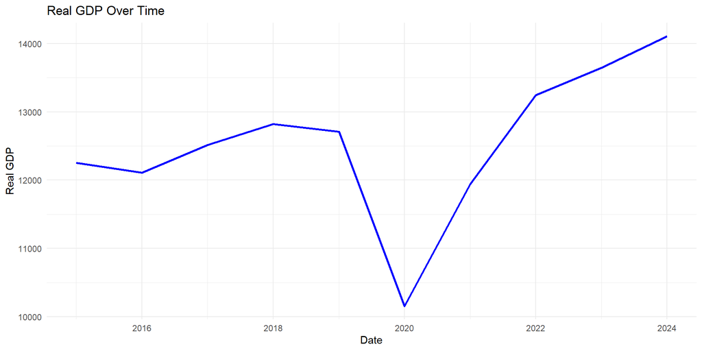

```r
ggplot(bhs_data, aes(x = date, y = real_gdp)) +
  geom_line(color = "blue", linewidth = 1) +
  labs(title = "Real GDP Over Time", x = "Date", y = "Real GDP") +
  theme_minimal()
```

# ggplot2 density function

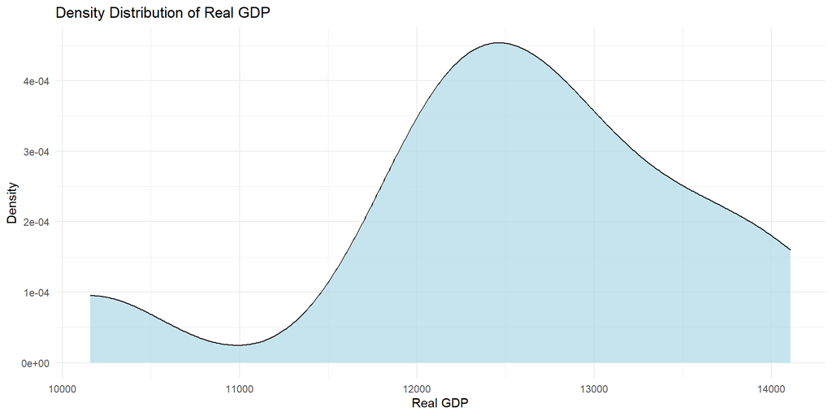

```r
ggplot(bhs_data, aes(x = real_gdp)) +
  geom_density(fill = "lightblue", alpha = 0.7) +
  labs(title = "Density Distribution of Real GDP", x = "Real GDP", y = "Density") +
  theme_minimal()
```

# ggplot2 scatter plot

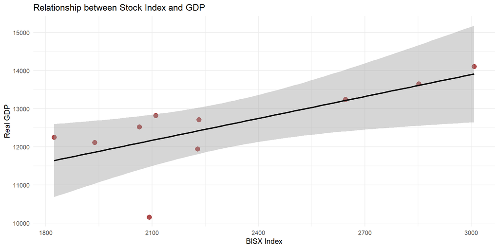

```r
ggplot(bhs_data, aes(y = real_gdp, x = bisx_index)) +
  geom_point(color = "darkred", size = 3, alpha = 0.7) +
  geom_smooth(method = "lm", se = TRUE, color = "black") +
  labs(title = "Relationship between Stock Index and GDP",
       x = "BISX Index", y = "Real GDP") +
  theme_minimal()
```

# Looping plots

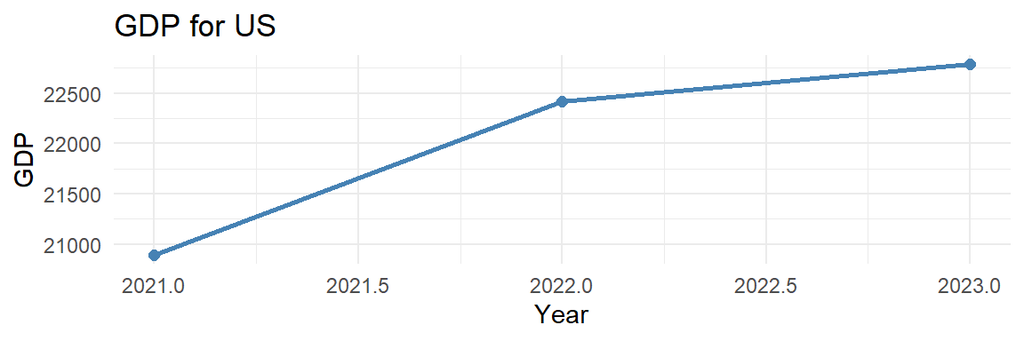

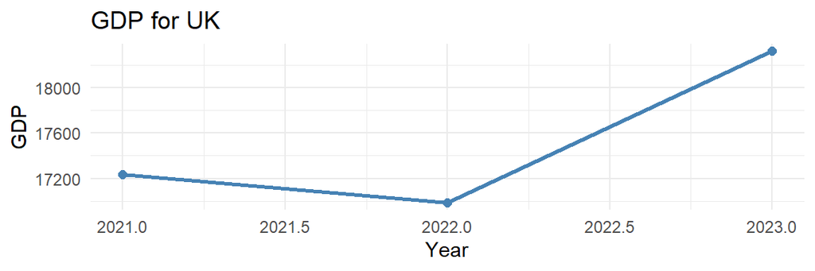

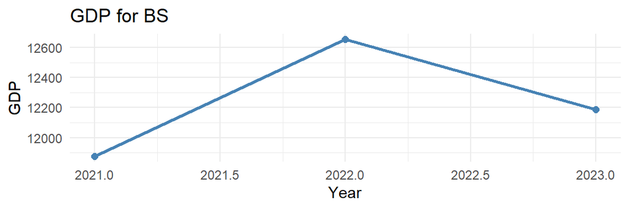

```r
for(c in unique(merged_df$country)) {
  temp <- merged_df %>% filter(country == c)
  print(
    ggplot(temp, aes(year, gdp)) +
      geom_line(color = "steelblue", linewidth = 1) +
      geom_point(color = "steelblue", size = 2) +
      labs(title = paste("GDP for", c), x = "Year", y = "GDP") +
      theme_minimal()
  )
}
```

# Activity

Using the US stocks and GDP files provided:

- Read (import) both files
- Clean the data (hint: check date columns data types)
- Join the data frames
- Obtain the average and standard deviation of the NASDAQ
- Make a scatter plot
- Write (export) the merged data frame as a .xlsx file